title=“Final Project - ALY 6010”

**Module 3 Assignment - GLM and Logistic Regression**

**Intermediate Analytics**

ALY 6015

**Maheswar Raju Narasaiah**

Professor Eric Gero

Date: 29 January, 2023

**1. INTRODUCTION**

In this assigment, we are going perform Exploratory Data Analysis and glm() function in R to fit a Logistic Regression model to perform classification.

We are going to further construct and analyze two regression models, interpret their results, and utilize diagnostic methods to identify and resolve any problems with the models.

**About the College Dataset**

The College dataset, sourced from the ISLR library, contains information on a large number of US colleges.

**Format:** A data frame with 777 observations on the following 18 variables.

Private: A factor with levels No and Yes indicating private or public university

Apps: Number of applications received

Accept: Number of applications accepted

Enroll: Number of new students enrolled

Top10perc: Pct. new students from top 10% of H.S. class

Top25perc: Pct. new students from top 25% of H.S. class

F.Undergrad: Number of fulltime undergraduates

P.Undergrad: Number of parttime undergraduates

Outstate: Out-of-state tuition

Room.Board: Room and board costs

Books: Estimated book costs

Personal: Estimated personal spending

PhD: Pct. of faculty with Ph.D.’s

Terminal: Pct. of faculty with terminal degree

S.F.Ratio: Student/faculty ratio

perc.alumni: Pct. alumni who donate

Expend: Instructional expenditure per student

Grad.Rate: Graduation rate

**2. ANALYSIS**

**2.2. Perform Exploratory Data Analysis and use descriptive statistics to describe the data.**

Exploratory Data Analysis (EDA) is performed in order to better understand the underlying structure of the data, and to identify patterns, relationships, and outliers in the data set (Bluman, 2014). It is an initial step in the data analysis process that helps to inform the decisions that will be made later in the analysis, such as which statistical models to use and which features to include in the models. Additionally, EDA can help to identify any issues or problems with the data, such as missing values or outliers, so that they can be addressed before modeling begins.

```r
#### Outcome of summarytools::descr()
###################################
table2.1 <- College %>%
    summarytools::descr()


# Rounding off the digits in Table
table1 <- round((table2.1), digits = 2)


# Present the table using kableExta Package
knitr::kable(table1,
    caption = "Table 1: Descriptive Statistics of College Using
    Code summarytools::descr() ",
    format = "html",
    table.attr = "style=width: 100%"
) %>%
    kable_styling(bootstrap_options = c(
        "striped", "hover",
        "condensed", "responsive"
    )) %>%
    kable_classic(
        full_width = T,
        html_font = "Times New Roman"
    )
```

Table 1: Descriptive Statistics of College Using Code summarytools::descr()

|  | Accept | Apps | Books | Enroll | Expend | F.Undergrad | Grad.Rate | Outstate | P.Undergrad | perc.alumni | Personal | PhD | Room.Board | S.F.Ratio | Terminal | Top10perc | Top25perc |
| --- | --- | --- | --- | --- | --- | --- | --- | --- | --- | --- | --- | --- | --- | --- | --- | --- | --- |
| Mean | 2018.80 | 3001.64 | 549.38 | 779.97 | 9660.17 | 3699.91 | 65.46 | 10440.67 | 855.30 | 22.74 | 1340.64 | 72.66 | 4357.53 | 14.09 | 79.70 | 27.56 | 55.80 |
| Std.Dev | 2451.11 | 3870.20 | 165.11 | 929.18 | 5221.77 | 4850.42 | 17.18 | 4023.02 | 1522.43 | 12.39 | 677.07 | 16.33 | 1096.70 | 3.96 | 14.72 | 17.64 | 19.80 |
| Min | 72.00 | 81.00 | 96.00 | 35.00 | 3186.00 | 139.00 | 10.00 | 2340.00 | 1.00 | 0.00 | 250.00 | 8.00 | 1780.00 | 2.50 | 24.00 | 1.00 | 9.00 |
| Q1 | 604.00 | 776.00 | 470.00 | 242.00 | 6751.00 | 992.00 | 53.00 | 7320.00 | 95.00 | 13.00 | 850.00 | 62.00 | 3597.00 | 11.50 | 71.00 | 15.00 | 41.00 |
| Median | 1110.00 | 1558.00 | 500.00 | 434.00 | 8377.00 | 1707.00 | 65.00 | 9990.00 | 353.00 | 21.00 | 1200.00 | 75.00 | 4200.00 | 13.60 | 82.00 | 23.00 | 54.00 |
| Q3 | 2424.00 | 3624.00 | 600.00 | 902.00 | 10830.00 | 4005.00 | 78.00 | 12925.00 | 967.00 | 31.00 | 1700.00 | 85.00 | 5050.00 | 16.50 | 92.00 | 35.00 | 69.00 |
| Max | 26330.00 | 48094.00 | 2340.00 | 6392.00 | 56233.00 | 31643.00 | 118.00 | 21700.00 | 21836.00 | 64.00 | 6800.00 | 103.00 | 8124.00 | 39.80 | 100.00 | 96.00 | 100.00 |
| MAD | 1008.17 | 1463.33 | 148.26 | 354.34 | 2730.95 | 1441.09 | 17.79 | 4121.63 | 449.23 | 13.34 | 593.04 | 17.79 | 1005.20 | 3.41 | 14.83 | 13.34 | 20.76 |
| IQR | 1820.00 | 2848.00 | 130.00 | 660.00 | 4079.00 | 3013.00 | 25.00 | 5605.00 | 872.00 | 18.00 | 850.00 | 23.00 | 1453.00 | 5.00 | 21.00 | 20.00 | 28.00 |
| CV | 1.21 | 1.29 | 0.30 | 1.19 | 0.54 | 1.31 | 0.26 | 0.39 | 1.78 | 0.54 | 0.51 | 0.22 | 0.25 | 0.28 | 0.18 | 0.64 | 0.35 |
| Skewness | 3.40 | 3.71 | 3.47 | 2.68 | 3.45 | 2.60 | -0.11 | 0.51 | 5.67 | 0.60 | 1.74 | -0.77 | 0.48 | 0.66 | -0.81 | 1.41 | 0.26 |
| SE.Skewness | 0.09 | 0.09 | 0.09 | 0.09 | 0.09 | 0.09 | 0.09 | 0.09 | 0.09 | 0.09 | 0.09 | 0.09 | 0.09 | 0.09 | 0.09 | 0.09 | 0.09 |
| Kurtosis | 18.75 | 26.52 | 28.06 | 8.74 | 18.59 | 7.61 | -0.22 | -0.43 | 54.52 | -0.11 | 7.04 | 0.54 | -0.20 | 2.52 | 0.22 | 2.17 | -0.57 |
| N.Valid | 777.00 | 777.00 | 777.00 | 777.00 | 777.00 | 777.00 | 777.00 | 777.00 | 777.00 | 777.00 | 777.00 | 777.00 | 777.00 | 777.00 | 777.00 | 777.00 | 777.00 |
| Pct.Valid | 100.00 | 100.00 | 100.00 | 100.00 | 100.00 | 100.00 | 100.00 | 100.00 | 100.00 | 100.00 | 100.00 | 100.00 | 100.00 | 100.00 | 100.00 | 100.00 | 100.00 |

```r
#### Outocome of psych::describe ()
###################################
table2.2 <- College %>%
    psych::describe() %>%
    t()


# Rounding off the digits in Table
table2 <- round((table2.2), digits = 1)


# Present the table using kableExta Package
knitr::kable(table2,
    caption = "Table 2: Descriptive Statistics of College Data Set Using
    Code psych::describe () ",
    format = "html",
    table.attr = "style=width: 40%",
    font_size = 8
) %>%
    kable_styling(bootstrap_options = c(
        "striped", "hover",
        "condensed", "responsive"
    )) %>%
    kable_classic(
        full_width = F,
        html_font = "Times New Roman"
    )
```

Table 2: Descriptive Statistics of College Data Set Using Code psych::describe ()

|  | Private* | Apps | Accept | Enroll | Top10perc | Top25perc | F.Undergrad | P.Undergrad | Outstate | Room.Board | Books | Personal | PhD | Terminal | S.F.Ratio | perc.alumni | Expend | Grad.Rate |
| --- | --- | --- | --- | --- | --- | --- | --- | --- | --- | --- | --- | --- | --- | --- | --- | --- | --- | --- |
| vars | 1.0 | 2.0 | 3.0 | 4.0 | 5.0 | 6.0 | 7.0 | 8.0 | 9.0 | 10.0 | 11.0 | 12.0 | 13.0 | 14.0 | 15.0 | 16.0 | 17.0 | 18.0 |
| n | 777.0 | 777.0 | 777.0 | 777.0 | 777.0 | 777.0 | 777.0 | 777.0 | 777.0 | 777.0 | 777.0 | 777.0 | 777.0 | 777.0 | 777.0 | 777.0 | 777.0 | 777.0 |
| mean | 1.7 | 3001.6 | 2018.8 | 780.0 | 27.6 | 55.8 | 3699.9 | 855.3 | 10440.7 | 4357.5 | 549.4 | 1340.6 | 72.7 | 79.7 | 14.1 | 22.7 | 9660.2 | 65.5 |
| sd | 0.4 | 3870.2 | 2451.1 | 929.2 | 17.6 | 19.8 | 4850.4 | 1522.4 | 4023.0 | 1096.7 | 165.1 | 677.1 | 16.3 | 14.7 | 4.0 | 12.4 | 5221.8 | 17.2 |
| median | 2.0 | 1558.0 | 1110.0 | 434.0 | 23.0 | 54.0 | 1707.0 | 353.0 | 9990.0 | 4200.0 | 500.0 | 1200.0 | 75.0 | 82.0 | 13.6 | 21.0 | 8377.0 | 65.0 |
| trimmed | 1.8 | 2193.0 | 1510.3 | 576.0 | 25.1 | 55.1 | 2574.9 | 536.4 | 10181.7 | 4301.7 | 535.2 | 1268.3 | 73.9 | 81.1 | 13.9 | 21.9 | 8823.7 | 65.6 |
| mad | 0.0 | 1463.3 | 1008.2 | 354.3 | 13.3 | 20.8 | 1441.1 | 449.2 | 4121.6 | 1005.2 | 148.3 | 593.0 | 17.8 | 14.8 | 3.4 | 13.3 | 2730.9 | 17.8 |
| min | 1.0 | 81.0 | 72.0 | 35.0 | 1.0 | 9.0 | 139.0 | 1.0 | 2340.0 | 1780.0 | 96.0 | 250.0 | 8.0 | 24.0 | 2.5 | 0.0 | 3186.0 | 10.0 |
| max | 2.0 | 48094.0 | 26330.0 | 6392.0 | 96.0 | 100.0 | 31643.0 | 21836.0 | 21700.0 | 8124.0 | 2340.0 | 6800.0 | 103.0 | 100.0 | 39.8 | 64.0 | 56233.0 | 118.0 |
| range | 1.0 | 48013.0 | 26258.0 | 6357.0 | 95.0 | 91.0 | 31504.0 | 21835.0 | 19360.0 | 6344.0 | 2244.0 | 6550.0 | 95.0 | 76.0 | 37.3 | 64.0 | 53047.0 | 108.0 |
| skew | -1.0 | 3.7 | 3.4 | 2.7 | 1.4 | 0.3 | 2.6 | 5.7 | 0.5 | 0.5 | 3.5 | 1.7 | -0.8 | -0.8 | 0.7 | 0.6 | 3.4 | -0.1 |
| kurtosis | -1.0 | 26.5 | 18.8 | 8.7 | 2.2 | -0.6 | 7.6 | 54.5 | -0.4 | -0.2 | 28.1 | 7.0 | 0.5 | 0.2 | 2.5 | -0.1 | 18.6 | -0.2 |
| se | 0.0 | 138.8 | 87.9 | 33.3 | 0.6 | 0.7 | 174.0 | 54.6 | 144.3 | 39.3 | 5.9 | 24.3 | 0.6 | 0.5 | 0.1 | 0.4 | 187.3 | 0.6 |

*Observations*

- The dataset includes statistics such as the mean, median, and mode for the variables being analyzed. The data shows that there are more full-time undergraduate students (31643) than part-time undergraduate students (21836). The highest percentage of new students from the top 10% of high school classes is 96%, and the lowest is 1%. The highest instructional expenditure per student is 56233 and the lowest is 3186.
- According to the descriptive analysis, the highest amount of applications received was 48094. Of those, 26330 were accepted and 6392 were enrolled. The average number of applications received was 3001. The lowest student-faculty ratio was 2.5, while the highest was 39.8. The maximum graduation rate was 118 and the minimum was 10. The average and median student-faculty ratio was 14.09 and 13.6 respectively, indicating a positive skew and positive kurtosis and skewness values.

**2.2. Boxplots of Outstate versus Private College**

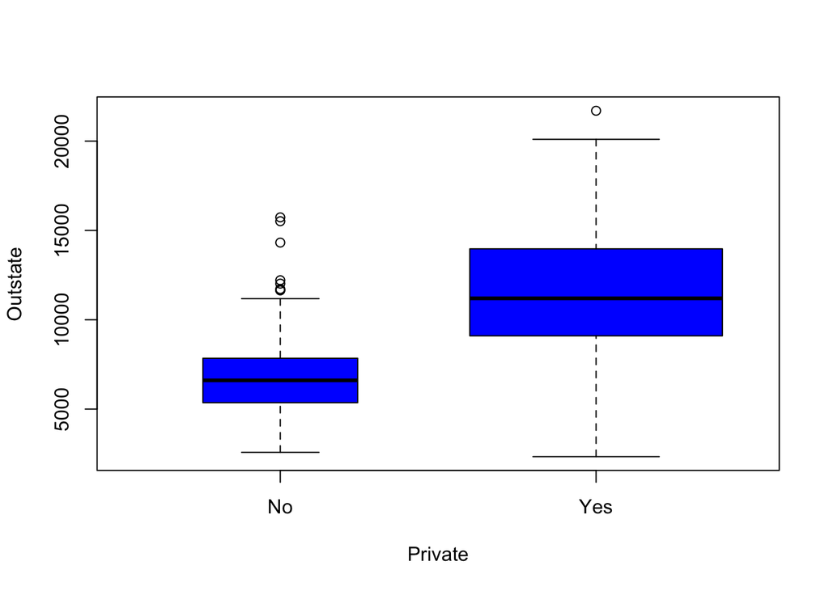

```r
#Use the plot() function to produce side-by-side boxplots of Outstate versus Private.

plot(College$Private,College$Outstate, col = "blue", varwidth = T, xlab = "Private", ylab = "Outstate")
```

**2.3. Boxplot for enrolments in Private and Public colleges**

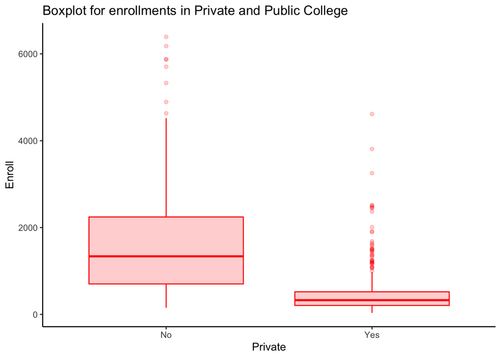

```r
ggplot(College,aes(Private, Enroll, fill =Private)) +
geom_boxplot(color="red", fill= "red", alpha = 0.2) +
ggtitle("Boxplot for enrollments in Private and Public College") +
scale_fill_brewer(palette ="Blues") + theme_classic()
```

*Observations*

- The box plot on Enrollments shows that public colleges have a higher enrollment rate compared to private colleges. This indicates that most students enrolled in private universities are below 1000, with outliers. The 95th percentile for private universities is also significantly lower than the maximum enrollment numbers for public universities.

**2.4. Histogram for various variable in College Database**

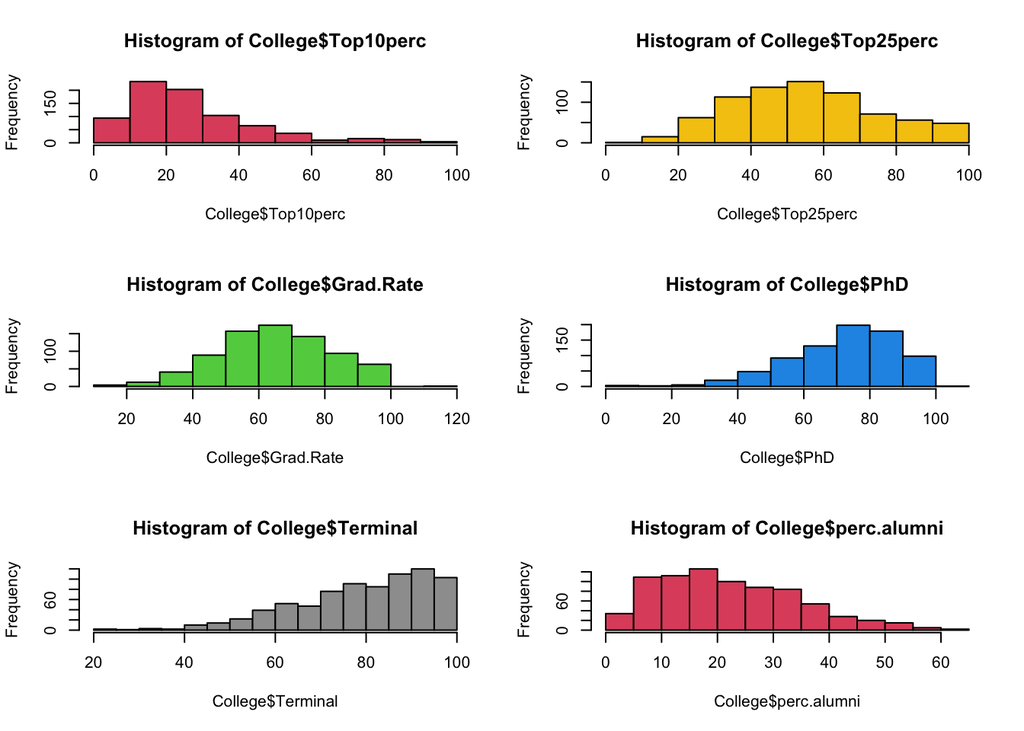

```r
# to devide the print window into four regions
par(mfrow=c(3,2))
# calling 4 hitograms
hist(College$Top10perc, col = 2)
hist(College$Top25perc, col =7)
hist(College$Grad.Rate, col = 3)
hist(College$PhD, col = 4)
hist(College$Terminal, col=8)
hist(College$perc.alumni, col=10)
```

**2.5. Distribution of Private and Public Universities**

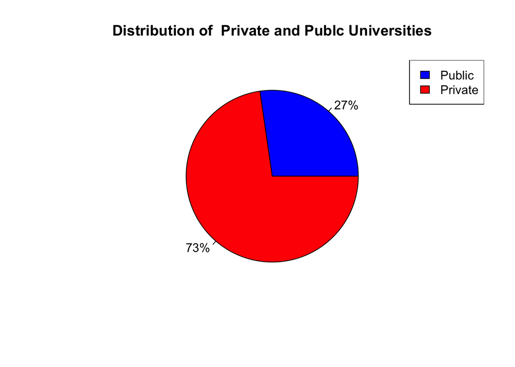

```r
# Calculate the counts of the "gear" variable
counts <- table(College$Private)

# Define the labels and colors for the pie chart
# Calculate the percentage values
percents <- counts / sum(counts)
# Format the percentage values as strings
labels <- paste0(round(percents * 100), "%")
colors <- c("blue","red")

# Create the pie chart
pie(counts, labels = labels, col = colors)
# Add a title to the pie chart
title("Distribution of  Private and Publc Universities")
# Add a legend to the pie chart
leg <- c("Public", "Private")
legend("topright", leg, fill = colors)
```

*Observations*

- The Pie Chart shows that private university are more prominenet than public university, Almost 73% of university in data set are private university.

**2.6. Scatter plot for Applications vs Accepted by Private and Public Colleges**

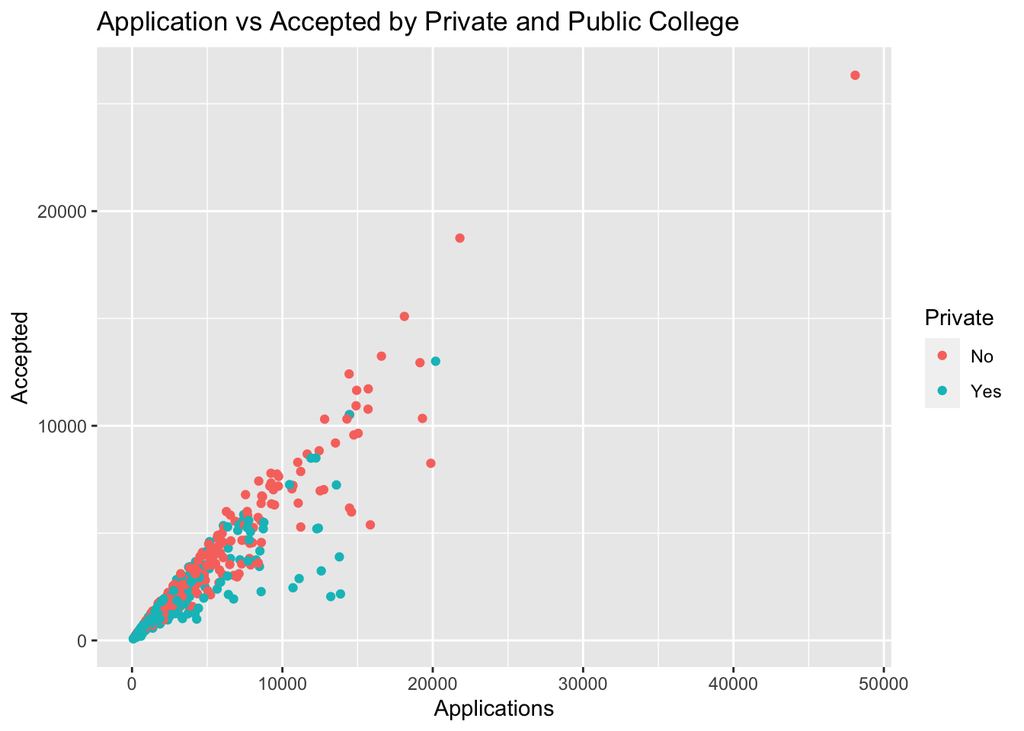

```r
ggplot(College,aes(x= Apps, y= Accept, col=Private)) +
geom_point() +
labs(title = "Application vs Accepted by Private and Public College",
 x= "Applications", y= "Accepted")
```

**2.7. Split the data into a Train and Test set**

The next step in the analysis process involves dividing the data into two distinct sets: a training set and a test set. This is accomplished by utilizing the createDataPartition() function on a private variable. This function separates the data into two parts, with 70% of the data being designated for training and the remaining 30% being set aside for testing the model. The selection of records for each set is done randomly, ensuring that the data is evenly distributed and unbiased. This step is crucial for accurately evaluating the performance of the model and ensuring that it can accurately predict outcomes on new, unseen data. By splitting the data in this manner, we can ensure that the model is properly trained and can make accurate predictions on the test set.

```r
#Split che data into a train and test set
#Initialize randonizer
set.seed(456)

#Get 70% of random row numbers
train_ind <- createDataPartition(College$Private, p=0.70, list= FALSE)

# Get training data which includes 70% of rows
train <- College [train_ind,]

#Get test data which include the rest 30%(i,e. excludes 708 of rows)
test= College[-train_ind,]
```

**2.8. Use the glm() function in the ‘stats’ package to fit a logistic regression model to the training set using at least two predictors.**

```r
#Fitting model
model1 = glm(as.factor(Private)~F.Undergrad+Outstate+PhD+perc.alumni,
data = train, family=binomial(link="logit"))

summary(model1)
```

```
##
## Call:
## glm(formula = as.factor(Private) ~ F.Undergrad + Outstate + PhD +
##     perc.alumni, family = binomial(link = "logit"), data = train)
##
## Deviance Residuals:
##     Min       1Q   Median       3Q      Max
## -3.6733  -0.0382   0.0554   0.1807   5.0923
##
## Coefficients:
##               Estimate Std. Error z value Pr(>|z|)
## (Intercept) -0.5262458  1.0036477  -0.524  0.60005
## F.Undergrad -0.0004208  0.0000643  -6.545 5.97e-11 ***
## Outstate     0.0008557  0.0001044   8.199 2.42e-16 ***
## PhD         -0.0716779  0.0167140  -4.288 1.80e-05 ***
## perc.alumni  0.0631523  0.0227188   2.780  0.00544 **
## ---
## Signif. codes:  0 '***' 0.001 '**' 0.01 '*' 0.05 '.' 0.1 ' ' 1
##
## (Dispersion parameter for binomial family taken to be 1)
##
##     Null deviance: 639.40  on 544  degrees of freedom
## Residual deviance: 185.68  on 540  degrees of freedom
## AIC: 195.68
##
## Number of Fisher Scoring iterations: 7
```

```r
#Regression Cofficient (Log -odds)
coef(model1)
```

```
##   (Intercept)   F.Undergrad      Outstate           PhD   perc.alumni
## -0.5262458410 -0.0004207898  0.0008557340 -0.0716779026  0.0631523167
```

```r
##Regression Cofficient (odds)
exp(coef(model1))
```

```
## (Intercept) F.Undergrad    Outstate         PhD perc.alumni
##   0.5908188   0.9995793   1.0008561   0.9308307   1.0651891
```

**2.9. Create a confusion matrix and report the results of your model for the train set.**

To compute a confusion matrix, a set of predictions must be obtained and compared to the target values. These predictions can be used to evaluate various metrics, such as Precision, Recall, F1 score, Accuracy, Precision, Recall, and Specificity (Visa et. al., 2011).

In this particular scenario, predictions were made on the training data set and a confusion matrix was generated as follows:

```r
#Creating A confusion Mtrix for Train Set
prob.train = predict(model1, newdata = train, type ="response")

pred.class.min.tr  <- as.factor(ifelse(prob.train >= 0.5, "Yes", "No"))

#Model Accurcay
confusionMatrix(pred.class.min.tr, as.factor(train$Private), positive ="Yes")
```

```
## Confusion Matrix and Statistics
##
##           Reference
## Prediction  No Yes
##        No  129  16
##        Yes  20 380
##
##                Accuracy : 0.9339
##                  95% CI : (0.9097, 0.9533)
##     No Information Rate : 0.7266
##     P-Value [Acc > NIR] : <2e-16
##
##                   Kappa : 0.8323
##
##  Mcnemar's Test P-Value : 0.6171
##
##             Sensitivity : 0.9596
##             Specificity : 0.8658
##          Pos Pred Value : 0.9500
##          Neg Pred Value : 0.8897
##              Prevalence : 0.7266
##          Detection Rate : 0.6972
##    Detection Prevalence : 0.7339
##       Balanced Accuracy : 0.9127
##
##        'Positive' Class : Yes
##
```

*Interpretation of Confusion Matrix*

- The confusion matrix is a tool used to evaluate the performance of a classification model. In this case, the model was created using a train data set. The matrix displays the number of correctly and incorrectly classified instances for each class (LaValley, 2008).
- The True Positives (TP) are 380, which means the model correctly identified 380 instances as the positive class. The True Negatives (TN) are 129, which means the model correctly identified 129 instances as the negative class.
- On the other hand, the False Positives (FP) are 20, which means the model incorrectly identified 20 instances as the positive class when they were actually negative. The False Negatives (FN) are 16, which means the model incorrectly identified 16 instances as the negative class when they were actually positive.

Overall, the model has a high accuracy rate with a large number of True Positives and True Negatives. However, it also has a relatively low number of False Positives and False Negatives, indicating that the model may be more prone to making errors when identifying instances of the negative class. To improve the performance of the model, further optimization and fine-tuning may be necessary.

*Which misclassifications are more damaging for the analysis, False Positives or False Negatives?*

It depends on the specific context and purpose of the analysis.

- False positives, also known as Type I errors, occur when a model incorrectly classifies a negative sample as positive. In some cases, such as medical diagnoses or fraud detection, false positives can have serious consequences and be considered more damaging.
- False negatives, also known as Type II errors, occur when a model incorrectly classifies a positive sample as negative. In some cases, such as disease screening or security threats, false negatives can also have serious consequences and be considered more damaging.

It’s important to consider the specific context and purpose of the analysis when determining which misclassifications are more damaging. For example, in a medical diagnosis, a false negative might be more damaging as it leads to delayed or missed treatment, whereas in a fraud detection system a false positive might be more damaging as it leads to wasted resources and potential loss of reputation.

*Report and interpret metrics for Accuracy, Precision, Recall, and Specificity*

- The confusion matrix is a tool used to evaluate the performance of a classification model. It helps to understand the number of true positive, false positive, true negative and false negative predictions made by the model. The accuracy of the model is 93.39%, which means that out of all the predictions made by the model, 93.39% of them are correct. This is considered to be a good accuracy rate.
- The precision of the model is 95.00%, which means that out of all the positive predictions made by the model, 95.00% of them are correct. This is considered to be a high precision rate, which means that the model is not making many false positive predictions.
- The recall of the model is 95.96%, which means that out of all the actual positive cases, the model is able to correctly identify 95.96% of them. This is considered to be a high recall rate, which means that the model is not missing many actual positive cases.
- The specificity of the model is 86.58%, which means that out of all the actual negative cases, the model is able to correctly identify 86.58% of them. This is considered to be a good specificity rate, which means that the model is not making many false negative predictions.
- The sensitivity of the model is 95.96%, which is the same as the recall rate. This means that the model is able to correctly identify 95.96% of the actual positive cases.

In summary, based on the confusion matrix, it is observed that the model is predicting accurately, with good accuracy, precision, recall, specificity, and sensitivity rates. This suggests that the model is able to make accurate predictions and is not making many false positive or false negative predictions.

**2.10. Create a confusion matrix and report the results of your model for the test set.**

```r
#Creating A confusion Mtrix for test Set
prob.test = predict(model1, newdata = test, type ="response")

pred.class.min.tst  <- as.factor(ifelse(prob.test >= 0.5, "Yes", "No"))

#Model Accurcay
confusionMatrix(pred.class.min.tst, as.factor(test$Private), positive ="Yes")
```

```
## Confusion Matrix and Statistics
##
##           Reference
## Prediction  No Yes
##        No   52   5
##        Yes  11 164
##
##                Accuracy : 0.931
##                  95% CI : (0.8904, 0.9601)
##     No Information Rate : 0.7284
##     P-Value [Acc > NIR] : 4.085e-15
##
##                   Kappa : 0.8203
##
##  Mcnemar's Test P-Value : 0.2113
##
##             Sensitivity : 0.9704
##             Specificity : 0.8254
##          Pos Pred Value : 0.9371
##          Neg Pred Value : 0.9123
##              Prevalence : 0.7284
##          Detection Rate : 0.7069
##    Detection Prevalence : 0.7543
##       Balanced Accuracy : 0.8979
##
##        'Positive' Class : Yes
##
```

**2.11. Plot and interpret the ROC curve from the data standpoint**

```r
roc_c  <- roc(test$Private, prob.test)
```

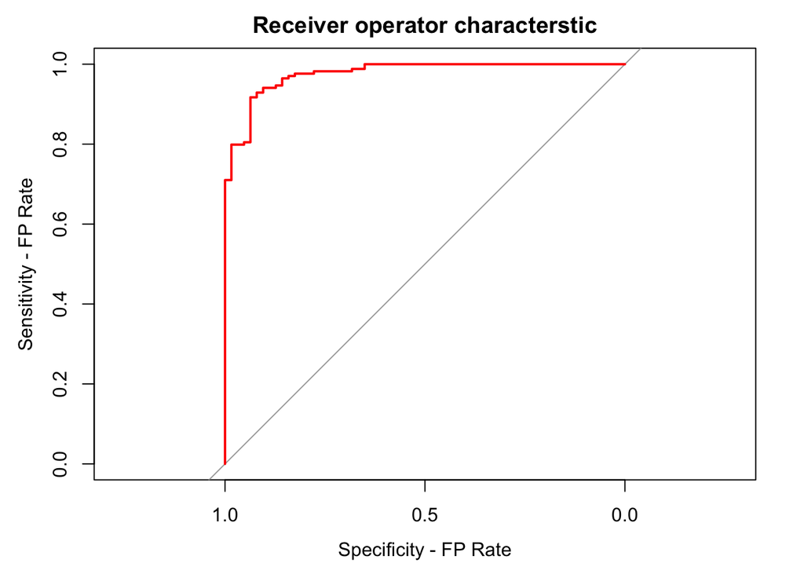

```r
plot(roc_c, col= "red", ylab = "Sensitivity - FP Rate",  xlab= "Specificity - FP Rate", main ="Receiver operator characterstic")
```

*Report and interpret metrics for Accuracy, Precision, Recall, and Specificity*

- A confusion matrix is a table that is used to define the performance of a classification algorithm. It is typically used in the context of binary classification, where the predicted output is either positive or negative. The confusion matrix contains four main elements: true positives (TP), true negatives (TN), false positives (FP), and false negatives (FN) (Park et. al., 2004).
- In the above ROC plot, the peak of the curve is closer to 1, which indicates that the model has a high true positive rate (sensitivity) and a low false positive rate (1-specificity). This means that the model is able to correctly identify a large number of positive instances while minimizing the number of false positives. In other words, the model is able to accurately distinguish between positive and negative instances.
- The true positive rate (sensitivity) measures the proportion of positive instances that are correctly identified by the model, while the false positive rate measures the proportion of negative instances that are incorrectly identified as positive. A high true positive rate and a low false positive rate indicate that the model is able to correctly identify a high proportion of positive instances while minimizing the number of false positives.

In summary, the above ROC plot indicates that the model is a good one as it is able to accurately distinguish between positive and negative instances with a high true positive rate and a low false positive rate.

**2.12. Calculate and interpret the AUC from the Data Standpoint**

```r
auc_c <- auc(roc_c)

auc_c
```

```
## Area under the curve: 0.9765
```

*Report and interpret metrics for Accuracy, Precision, Recall, and Specificity*

- In this case, the confusion matrix for the model shows an AUC of 97.65%. This means that the model is able to correctly predict the outcome of the data with a high degree of accuracy.
- The AUC value is calculated by comparing the true positive rate (TPR) and the false positive rate (FPR) of the model. The TPR represents the number of true positive predictions made by the model, while the FPR represents the number of false positive predictions made by the model. A high TPR and a low FPR indicate that the model is able to accurately predict the outcome of the data.
- In this case, the model is able to predict 1s as 1s and 0s as 0s with a high degree of accuracy. This is evident from the high AUC value of 97.65%. This means that the model is able to correctly identify the positive and negative outcomes of the data with a high degree of accuracy. The high AUC value indicates that the model is a good model, and it can be used to make accurate predictions on new data.

Overall, the confusion matrix in this case shows that the model is able to accurately predict the outcome of the data, and it is a good model for making predictions on new data. The high AUC value of 97.65% is a clear indication of the model’s high accuracy and reliability.

**3. CONCLUSIONS**

**4. REFERENCES**

- Visa, S., Ramsay, B., Ralescu, A. L., & Van Der Knaap, E. (2011). Confusion matrix-based feature selection. Maics, 710(1), 120-127.
- Gomes, M. M. (2018, June 14). Data Visualization: Best Practices and Foundations. Toptal Design Blog. https://www.toptal.com/designers/data-visualization/data-visualization-best-practices
- Bluman, A. (2014). Elementary Statistics: A step by step approach 9e. McGraw Hill.
- LaValley, M. P. (2008). Logistic regression. Circulation, 117(18), 2395-2399.
- Park, S. H., Goo, J. M., & Jo, C. H. (2004). Receiver operating characteristic (ROC) curve: practical review for radiologists. Korean journal of radiology, 5(1), 11-18.